### Algorithmic Machine Learning Challenge

# Plankton Image Classification

Plankton comprises all the organisms freely drifting with ocean currents. These life forms are a critically important piece of oceanic ecosystems, accounting for more than half the primary production on earth and nearly half the total carbon fixed in the global carbon cycle. They also form the foundation of aquatic food webs, including those of large, commercially important fisheries. Loss of plankton populations could result in ecological upheaval as well as negative societal impacts, particularly in indigenous cultures and the developing world. Plankton’s global significance makes their population levels an ideal measure of the health of the world’s oceans and ecosystems.

Traditional methods for measuring and monitoring plankton populations are time consuming and cannot scale to the granularity or scope necessary for large-scale studies. Improved approaches are needed. One such approach is through the use of underwater imagery sensors.

In this challenge, which was prepared in cooperation with the Laboratoire d’Océanographie de Villefranche, jointly run by Sorbonne Université and CNRS, plankton images were acquired in the bay of Villefranche, weekly since 2013 and manually engineered features were computed on each imaged object.

This challenge aims at developing solid approaches to plankton image classification. We will compare methods based on carefully (but manually) engineered features, with “Deep Learning” methods in which features will be learned from image data alone.

The purpose of this challenge is for you to learn about the commonly used paradigms when working with computer vision problems. This means you can choose one of the following paths:

- Work directly with the provided images, e.g. using a (convolutional) neural network
- Work with the supplied features extracted from the images (*native* or *skimage* or both of them)
- Extract your own features from the provided images using a technique of your choice

You will find a detailed description about the image data and the features at the end of this text. In any case, the choice of the classifier that you decide to work with strongly depends on the choice of features.

Please bear in mind that the purpose of this challenge is not simply to find the best-performing model that was released on e.g. Kaggle for a similar problem. You should rather make sure to understand the dificulties that come with this computer vision task. Moreover, you should be able to justify your choice of features/model and be able to explain its advantages and disadvantages for the task.

# Overview

Beyond simply producing a well-performing model for making predictions, in this challenge we would like you to start developing your skills as a machine learning scientist. In this regard, your notebook should be structured in such a way as to explore the five following tasks that are expected to be carried out whenever undertaking such a project. The description below each aspect should serve as a guide for your work, but you are strongly encouraged to also explore alternative options and directions. Thinking outside the box will always be rewarded in these challenges.

### 1. Data Exploration

The first broad component of your notebook should enable you to familiarise yourselves with the given data, an outline of which is given at the end of this challenge specification.

What is new in this challenge is that you will be working with image data. Therefore, you should have a look at example images located in the *imgs.zip* file (see description below). If you decide to work with the native or the skimage features, make sure to understand them!

Among others, this section should investigate:

- Distribution of the different image dimensions (including the number of channels)
- Distribution of the different labels that the images are assigned to

The image labels are organized in a taxonomy. We will measure the final model performance for the classification into the *level2* categories. Make sure to understand the meaning of this label inside the taxonomy.

### 2. Data Pre-processing

The previous step should give you a better understanding of which pre-processing is required for the data based on your approach:

- If you decide to work with the provided features, some data cleaning may be required to make full use of all the data.
- If you decide to extract your own features from the images, you should explain your approach in this section.
- If you decide to work directly with the images themselves, preprocessing the images may improve your classification results. In particular, if you work with a neural network the following should be of interest to you:
  - Due to the fully-connected layers (that usually come after the convolutional ones), the input needs to have a fixed dimension.
  - Data augmentation (image rotation, scaling, cropping, etc. of the existing images) can be used to increase the size of the training data set. This may improve performance especially when little data is available for a particular class.
  - Be aware of the computational cost! It might be worth rescaling the images to a smaller size!

  All of the operations above are usually realized using a dataloader. This means that you do not need to create a modified version of the dataset and save it to disk. Instead, the dataloader processes the data "on the fly" and in-memory before passing it to the network.

  NB: Although aligning image sizes is necessary to train CNNs, this will prevent your classifier from learning about different object sizes as a feature. Additional gains may be achieved when also taking object sizes into account.

### 3. Model Selection

Perhaps the most important segment of this challenge involves the selection of a model that can successfully handle the given data and yield sensible predictions. Instead of focusing exclusively on your final chosen model, it is also important to share your thought process in this notebook by additionally describing alternative candidate models.

The choice of your model is closely connected to the way you preprocessed the input data.

Furthermore, there are other factors which may influence your decision:

- What is the model's complexity?
- Is the model interpretable?
- Is the model capable of handling different data-types?
- Does the model return uncertainty estimates along with predictions?

### 4. Parameter Optimisation

Irrespective of your choice, it is highly likely that your model will have one or more (hyper-)parameters that require tuning. There are several techniques for carrying out such a procedure, including cross-validation, Bayesian optimisation, and several others. As before, an analysis into which parameter tuning technique best suits your model is expected before proceeding with the optimisation of your model.

If you use a neural network, the optimization of hyperparameters (learning rate, weight decay, etc.) can be a very time-consuming process. In this case, your may decide to carry out smaller experiments and to justify your choice on these preliminary tests.

### 5. Model Evaluation

Some form of pre-evaluation will inevitably be required in the preceding sections in order to both select an appropriate model and configure its parameters appropriately. In this final section, you may evaluate other aspects of the model such as:

- Assessing the running time of your model;
- Determining whether some aspects can be parallelised;
- Training the model with smaller subsets of the data.
- etc.

For the evaluation of the classification results, you should use the F1 measure (see Submission Instructions). Here the focus should be on level2 classification. A classification evaluation for other labels is optional.

Please note that you are responsible for creating a sensible train/validation/test split. There is no predefined held-out test data.

**N.B.** Please note that the items listed under each heading are neither exhaustive, nor are you expected to explore every given suggestion. Nonetheless, these should serve as a guideline for your work in both this and upcoming challenges. As always, you should use your intuition and understanding in order to decide which analysis best suits the assigned task.

## Submission Instructions

- The goal of this challenge is to construct a model for predicting Plankton (taxonomy level 2) classes.
- Your submission will be the **HTML version of your notebook** exploring the various modelling aspects described above.
- At the end of the notebook you should indicate your final evaluation score on a held-out test set. As an evaluation metric you should use the F1 score with the *average=macro* option as it is provided by the scikit-learn library. See the following link for more information:

https://scikit-learn.org/stable/modules/generated/sklearn.metrics.f1_score.html

## Dataset Description

#### * Location of the Dataset on zoe

The data for this challenge is located at: `/mnt/datasets/plankton/flowcam`

#### * Hierachical Taxonomy Tree for Labels

Each object is represented by a single image and is identified by a unique integer number. It has a name associated to it which is integrated in a hierarchical taxonomic tree. The identifications are gathered from different projects, classified by different people in different contexts, so they often target different taxonomic levels. For example, let us say we classify items of clothing along the following tree

```
top
    shirt
        long sleeves
        short sleeves
    sweater
        hooded
        no hood
bottom
    pants
        jeans
        other
    shorts
```

In a first project, images are classified to the finest level possible, but it may be the case that, on some pictures, it is impossible to determine whether a sweater has a hood or not, in which case it is simply classified as `sweater`. In the second project, the operator classified tops as `shirt` or `sweater` only, and bottoms to the finest level. In a third project, the operator only separated tops from bottoms. In such a context, the original names in the database cannot be used directly because, for example `sweater` will contain images that are impossible to determine as `hooded` or `no hood` *as well as* `hooded` and `no hood` images that were simply not classified further. If all three classes (`sweater`, `hooded`, and `no hood`) are included in the training set, it will likely confuse the classifier. For this reason, we define different target taxonomic levels:

- `level1` is the finest taxonomic level possible. In the example above, we would include `hooded` and `no hood` but discard all images in `sweater` to avoid confusion; and proceed in the same manner for other classes.
- `level2` is a grouping of underlying levels. In the example above, it would include `shirt` (which contains all images in `shirt`, `long sleeves`, and `short sleeves`), `sweater` (which, similarly would include this class and all its children), `pants` (including children), and `shorts`. So typically, `level2` contains more images (less discarding), sorted within fewer classes than `level1`, and may therefore be an easier classification problem.
- `level3` is an even broader grouping. Here it would be `top` vs `bottom`
- etc.

In the Plankton Image dataset, the objects will be categorised based on a pre-defined 'level1' and 'level2'. You can opt to work on one of them, but we recommend you to work on `level2` because it is an easier classification problem.

#### * Data Structure

```
/mnt/datasets/plankton/flowcam/
    meta.csv
    taxo.csv
    features_native.csv.gz
    features_skimage.csv.gz
    imgs.zip
```

- `meta.csv` contains the index of images and their corresponding labels
- `taxo.csv` defines the taxonomic tree and its potential groupings at various level. Note that, the information is also available in `meta.csv`. Therefore, the information in `taxo.csv` is probably useless, but at least it gives you a global view about taxonomy tree
- `features_native.csv.gz` contain the morphological handcrafted features computed by ZooProcess. In fact, ZooProcess generates the region of interests (ROI) around each individual object from a original image of Plankton. In addition, it also computes a set of associated features measured on the object. These features are the ones contained in `features_native.csv.gz`
- `features_skimage.csv.gz` contains the morphological features recomputed with skimage.measure.regionprops on the ROIs produced by ZooProcess.
- `imgs.zip` contains a post-processed version of the original images. Images are named by `objid`.jpg

#### * Attributes in meta.csv

The file contains the image identifiers (objid) as well as the labels assigned to the images by human operators. Those are defined with various levels of precision:

- *unique_name*: raw labels from operators
- *level1*: cleaned, most detailed labels
- *level2*: regrouped (coarser) labels
- *lineage*: full taxonomic lineage of the class

Some labels may be missing (coded ‘NA’) at a given level, meaning that the corresponding objects should be discarded for the classification at this level.

#### * imgs.zip

This zip archive contains an *imgs* folder that contains all the images in .jpg format. Do not extract this folder to disk! Instead you will be loading the images to memory. See the code below for a quick how-to:

```python
import zipfile
from io import BytesIO
from PIL import Image #to manipulate the images
import numpy as np

def extract_zip_to_memory(input_zip):
    '''
    This function extracts the images stored inside the given zip file.
    It stores the result in a python dictionary.

    input_zip (string): path to the zip file

    returns (dict): {filename (string): image_file (bytes)}
    '''
    input_zip=zipfile.ZipFile(input_zip)
    return {name: BytesIO(input_zip.read(name)) for name in input_zip.namelist() if name.endswith('.jpg')}


img_files = extract_zip_to_memory("/mnt/datasets/plankton/flowcam/imgs.zip")

# Display an example image
# Image.open(img_files['imgs/32738710.jpg'])

# Load the image as a numpy array:
# np_arr = np.array(Image.open(img_files['imgs/32738710.jpg']))

# Be aware that the dictionary will occupy roughly 2GB of computer memory!
# To free this memory again, run:
# del img_files
```

### Libraries Importation

```python
import pandas as pd
import glob
import os
import matplotlib.pyplot as plt
import matplotlib.image as mpimg
import warnings
warnings.filterwarnings("ignore")
%matplotlib inline

from sklearn.model_selection import train_test_split
import itertools

from keras.utils.np_utils import to_categorical # convert to one-hot-encoding
from keras.models import Sequential
from keras.layers import Dense, Dropout, Flatten, Conv2D, MaxPooling2D
from keras.optimizers import Adam
from keras.preprocessing.image import ImageDataGenerator
from keras.callbacks import ReduceLROnPlateau

#for padding and resizing steps
from skimage import data, color
from skimage.transform import rescale, resize, downscale_local_mean
```

### Approach

In this lab, we chose to work with the images and work with a CNN. Indeed, CNN is widely used and we were interested in discovering how it works more deeply and how to implement it.  
In this lab, we first studied the images and looked at the distribution of the labels we have to predict over the data.  
Then, we pre-processed the images to put them at the same size and dealt with the skewness thanks to data auagmentation.  
Finally, we built the CNN, studied the best parameters and looked more deeply into what happened during the prediction phase to better understand the model.

### 1. Data Exploration

```python
#number of images in the dataset (img_files is a dictionnary)
print("We have %s images in our dataset." % len(img_files))
```

```
We have 243610 images in our dataset.
```

#### Let's go deeper in the exploration of the images and their labels "level2".

**We want to see the id of images and their corresponding labels thanks to the meta.csv file.**

```python
#creation of the dataframe which contains objid and level2 values
meta=pd.read_csv("/mnt/datasets/plankton/flowcam/meta.csv")
train=meta[['objid','level2']] #create a dataframe with the two features of interest
print("We have %s images in the dataset." % train.shape[0])
```

```
We have 243610 images in the dataset.
```

**We look closer to the label values.**

```python
#look at the level2 values
print(train.level2.unique())
print("\n")
print("We have %s classes." % len(train.level2.unique()))
```

```
['detritus' 'Rhizosolenids' 'silks' 'feces' 'Codonaria' 'Asterionellopsis'
 'Codonellopsis (Dictyocystidae)' 'Dictyocysta' 'Neoceratium' 'Copepoda'
 'Coscinodiscids' 'nauplii (Crustacea)' 'Protoperidinium' 'Annelida'
 'Ceratocorys horrida' 'Dinophysiales' 'Chaetoceros' 'Thalassionema'
 'Undellidae' 'rods' 'Hemiaulus' 'Tintinnidiidae' nan 'pollen' 'Retaria'
 'multiple (other)' 'Rhabdonella' 'chainlarge' 'artefact' 'Pleurosigma'
 'Odontella (Mediophyceae)' 'centric' 'Cyttarocylis' 'badfocus (artefact)'
 'egg (other)' 'Stenosemella' 'Xystonellidae' 'Lithodesmioides'
 'tempChaetoceros danicus' 'Bacteriastrum']


We have 40 classes.
```

**We get rid of the the images for which the level2 value is "nan".**

```python
reduced_data=train.dropna()
print("We have %s images left in the dataset." % reduced_data.shape[0])
```

```
We have 242607 images left in the dataset.
```

```python
print("We lost %s" % ((train.shape[0]-reduced_data.shape[0])*100/train.shape[0]),"% of our data.")
```

```
We lost 0.4117236566643405 % of our data.
```

```python
print("We have %s classes left." % len(reduced_data.level2.unique()))
```

```
We have 39 classes left.
```

```python
#WE FREE THE MEMORY
del  meta
del train
```

**Let's see the distribution of the level2 values over the data.**

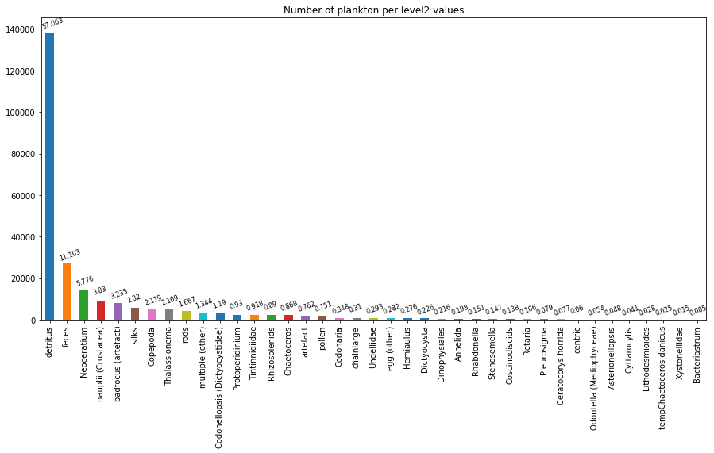

```python
fig, ax = plt.subplots(figsize=(15,7))

reduced_data['level2'].value_counts().plot(kind='bar', ax=ax)
ax.set_title('Number of plankton per level2 values')

#print the representation of the class in %
txt = [round(i,3) for i in (reduced_data['level2'].value_counts()/reduced_data.shape[0]*100)]
# Text on the top of each barplot
for i in range(len(reduced_data['level2'].value_counts())):
    plt.text(x=i-0.5, y=reduced_data['level2'].value_counts()[i]+5000, s = txt[i], size=8,rotation = 20)

plt.show()
```

We see that the class detritus represents more than 57% of the images of the dataset. This can be a problem while we train the model because the model can become very specific on the detritus class and not good enough for the under-represented classes.  
The data is really unbalanced here. To deal with this problem, we can think of :

Oversampling : Simply replicating randomly samples from minority classes won't be a good idea because some classes have very few images so for these classes, the algorithm will overfit on those few images.

Oversampling and data augmentation : increasing the number of images from the present images by slightly modifying the original images (eg. rotations...)

Also, we can pick images with a weight defined as the inverse of the frequency of the class to pick image classes more equally.

NB:It is important to note that having an unbalanced dataset is maybe a good thing because it represents, somehow, the reality : so having a neural network that focuses more on detritus class is a good thing since it is the most common thing we see in the sea. In our case, we get rid of some images because of computationnal issues.

```python
#get the index of images which have level2=detritus to get rid of 70% of them
indexNames = reduced_data[reduced_data['level2'] == 'detritus' ].index
print("We had %d images of detritus." %len(indexNames))
indexNames=np.array(indexNames)
a=np.random.choice(indexNames, size=int(len(indexNames)*70/100))
print("Now we have %d images of detritus." %len(a))
# Delete these row indexes in the dataFrame
reduced_data.drop(a , inplace=True)
```

```
We had 138439 images of detritus.
Now we have 96907 images of detritus.
```

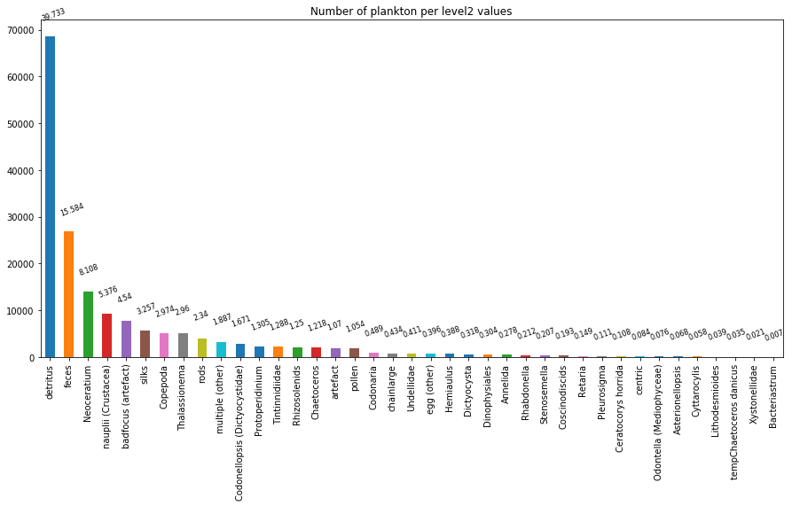

```python
#display
fig, ax = plt.subplots(figsize=(15,7))

reduced_data['level2'].value_counts().plot(kind='bar', ax=ax)
# ax.set_xlabel('Number of planktons having this label')
ax.set_title('Number of plankton per level2 values')

#print the representation of the class in %
txt = [round(i,3) for i in (reduced_data['level2'].value_counts()/reduced_data.shape[0]*100)]
# Text on the top of each barplot
for i in range(len(reduced_data['level2'].value_counts())):
    plt.text(x=i-0.5, y=reduced_data['level2'].value_counts()[i]+5000, s = txt[i], size=8,rotation = 20)

plt.show()
```

```python
print("We have %s images left in the dataset." % reduced_data.shape[0])
```

```
We have 172845 images left in the dataset.
```

#### Let's take a look at the size of the images

```python
#creation of arrays containing the width, the height and the mode for each image of the dataset
width=[]
height=[]
mode=[]
name=[]
for i in img_files:
    img=Image.open(img_files[i])
    width.append(img.width)
    height.append(img.height)
    mode.append(img.mode)
```

```
25th perc. width :  49.0
25th perc. height :  61.0
50th perc. width :  67.0
50th perc. height :  87.0
75th perc. width :  104.0
75th perc. height :  135.0
95th perc. width :  207.0
95th perc. height :  255.0
```

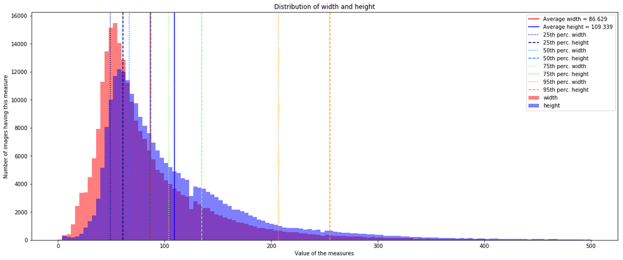

```python
plt.figure(figsize=(20,8))

#NB: we print until 500 to zoom, so we don't display extremely high width and height values
plt.hist(width, bins='rice', color='r', alpha=0.5, label='width',range=(0,500))
plt.hist(height, bins='rice', color='b', alpha=0.5, label='height',range=(0,500))

plt.axvline(np.mean(width), label='Average width = %.3f' % np.mean(width), linestyle="-", color ='r')
plt.axvline(np.mean(height), label='Average height = %.3f' % np.mean(height), linestyle="-", color ='b')
# Plot some percentile
for i, quantile in enumerate([0.25, .5, 0.75, .95]):
    plt.axvline(np.percentile(width, quantile*100), label='%.0fth perc. width' %(quantile*100), linestyle=":", color= plt.cm.jet(np.linspace(0,1,5))[i])
    plt.axvline(np.percentile(height, quantile*100), label='%.0fth perc. height' %(quantile*100), linestyle="--", color= plt.cm.jet(np.linspace(0,1,5))[i])
    print('%.0fth perc. width : ' %(quantile*100), np.percentile(width, quantile*100))
    print('%.0fth perc. height : ' %(quantile*100), np.percentile(height, quantile*100))
plt.legend(loc='upper right')
plt.title("Distribution of width and height")
plt.xlabel("Value of the measures")
plt.ylabel("Number of images having this measure")
plt.show()
```

```python
print("Mean width=",np.mean(width))
print("Mean height=", np.mean(height))
print("Median width=",np.median(width))
print("Median height=", np.median(height))
```

```
Mean width= 86.62893559377694
Mean height= 109.33858216000985
Median width= 67.0
Median height= 87.0
```

```python
np.unique(mode)
```

```
array(['L'], dtype='<U1')
```

We see that all our images are black and white (L means luminance for greyscale images).  
The mean width is 87 pixels and the mean height is 109 pixels.  
Let's look at the picture to see their shape (square or rectangular).

```python
#WE FREE OUR MEMORY
del width
del height
del mode
```

#### Let's visualise 3 images of each categories.

```python
feat_print=[] #will take all images converted in array of integers
targets = [] #will contain the corresponding class

values = reduced_data.level2.unique()
dico = dict(enumerate(values.flatten(), 1))

# Iterate over the keys of the labels dictionary defined in the above cell
for k in dico.values():
    samples = reduced_data[reduced_data["level2"] == k].head(3) # Get 3 samples for each category
    for j, s in enumerate(samples.values): # Append the samples to the samples list
        row_id = s[0] #get the objid of the row
        row_label = s[1] #get the corresponding level of this row
        name = ('imgs/'+str(int(row_id))+'.jpg') # contains the name of the corresponding image in the dataset
        feat_print.append(np.array(Image.open(img_files[name]))) # add the corresponding image array in features
        targets.append(row_label)
feat_print = np.array(feat_print)
targets = np.array(targets)

print("features shape", feat_print.shape)
print("targets shape", targets.shape)
```

```
features shape (117,)
targets shape (117,)
```

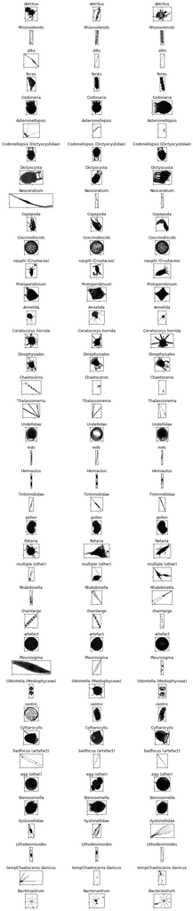

```python
#visualise the images
n=len(feat_print)
for a in range(n):
    ax=plt.subplot(round(n/3+0.3), 3, a+1)
    ax.imshow(feat_print[a],cmap='gray') #display images in black and white (as it is in the dataset)
    #get rid of the axis labels
    ax.set_xticklabels([])
    ax.set_yticklabels([])
    plt.title(targets[a])
plt.subplots_adjust(left  = 0.125,right =1.5, bottom = 0, top = 10, wspace = 0.2,hspace = 0.7)
plt.show()
```

Some classes have very specific caracteristics (Bacteriastum looks like stars, chainlarge is long and striped) and some other are more difficult to recognize (eg. Codonaria looks like Cyttarolylis ).  
Also, generally speaking, images of the same class have the same shape. Generally, the shape is a square or a lengthened rectangle.  
That is why it can be interesting to keep this caracteristic when we resize all images at the same shape : instead of extending or reducing the image size, we will either extend it to some extent and pad what is left or reduce it and pad what is left.

### 2. Data Pre-processing

#### Padding & Resize

```python
#This function checks the image is included in the (30,30) size
def check_dimension(width,height,size):
    if (width<= size and height <= size):
        return True
    else:
        return False


#This function resizes the pictures bigger then (30,30) and does the padding after for all the images
def rescale_plankton(plankton,width,height,size):
    if check_dimension(width,height,size):
        #We do a division here so that we can keep the image in the CENTER of the padding, so that we can apply DATA AUGMENTATION
        #We can then use rotation and translation for example without loosing the content of the image
        plankton = resize(plankton,(height,width))
        q_1,r_1 = divmod(size-height,2)
        q_2,r_2 = divmod(size-width,2)
        return np.pad(plankton,pad_width=((q_1, r_1+q_1), (q_2,r_2+q_2)), mode='constant',constant_values=1)
    else:
        for i in range(50,0,-1): # i goes from 50 to 1
            width_new = round(width*i/50)
            height_new = round(height*i/50)
            if (width_new ==0):
                width_new = 1
            if (height_new ==0):
                height_new = 1

            if check_dimension(width_new,height_new,size):
                planktona = resize(plankton,(height_new,width_new))
                q_1,r_1 = divmod(size-height_new,2)
                q_2,r_2 = divmod(size-width_new,2)
                return np.pad(planktona,pad_width=((q_1, r_1+q_1), (q_2,r_2+q_2)), mode='constant',constant_values=1)

#This function iterates over all the images and applies the function defined above
def pad_resize_features(features,size):
    for i in range(len(features)):
        features[i] = rescale_plankton(features[i],features[i].shape[1],features[i].shape[0],size)
    return np.array(features)
```

```python
#we free some space in the memory
del feat_print
del targets
```

#### [Just for us to test model drafts] Taking good samples from the dataset

**When testing, we don't use all the dataset to reduce the computation time. The following lines aims at being sure to get all the level2 values for a sample of the dataset, so that the results are more representative of hat will happen with the whole dataset.**

```python
# #create a dataframe which contains 3 columns : level2, count, weights (level2 properties)
# a=reduced_data['level2'].value_counts().to_frame().rename(index=str, columns={"level2": "count"})
# #the weight of a class is defined as the following : 1/(frequence of the class)
# a['weights']=reduced_data['level2'].value_counts().sum()/a['count']

# #create a dataframe with 4 columns : level2, objid, count and weights (images properties)
# b=reduced_data.set_index('level2').join(a.set_index(a.index))
# b.reset_index( inplace=True)
# b.rename(columns={"index": "level2"},inplace=True)
# #take n images from the oriiginal dataset, picking images with a probability proportioanl to the weight
# reduced_data=b.sample(n=80000, frac=None, replace=False, weights='weights', random_state=1, axis=0)
# # reduced_data[:5]
# # len(b['level2'].unique())
```

```python
# fig, ax = plt.subplots(figsize=(15,7))

# reduced_data['level2'].value_counts().plot(kind='bar', ax=ax)
# # ax.set_xlabel('Number of planktons having this label')
# ax.set_title('Number of plankton per level2 values')

# #print the representation of the class in %
# txt = [round(i,3) for i in (reduced_data['level2'].value_counts()/reduced_data.shape[0]*100)]
# # Text on the top of each barplot
# for i in range(len(reduced_data['level2'].value_counts())):
#      plt.text(x=i-0.5, y=reduced_data['level2'].value_counts()[i]+3, s = txt[i], size=8,rotation = 20)

# plt.show()
```

#### Encoding the level2 values

We need to do this step because the model will deal with numbers and not string.  
Each level2 values will be assigned to one number between 0 and 38 in the integer encoding step. In the one-hot encoding step, this number will be converted in an array containing a 1 at the index=number and 0 elsewhere.

```python
from numpy import array
from numpy import argmax
from sklearn.preprocessing import LabelEncoder
from sklearn.preprocessing import OneHotEncoder

values = reduced_data.level2.unique() #We take all the distinct level 2 categories

# INTEGER ENCODING
label_encoder = LabelEncoder()
integer_encoded = label_encoder.fit_transform(values) #transform the 39 level2 categories into integers (from 0 to 39)

values=label_encoder.inverse_transform(sorted(integer_encoded)) #reorder the values for the confusion matrix plot

# ONE-HOT ENCODING
onehot_encoder = OneHotEncoder(sparse=False)
integer_encoded = integer_encoded.reshape(len(integer_encoded), 1)
onehot_encoded = onehot_encoder.fit_transform(integer_encoded)

#WE TAKE EACH VALUE AND TRANSFROM IT TO A ONE-HOT ENCODING ARRAY
for category in values :
    cat_int = label_encoder.transform([category]) # cat_int is an array containing only one element : the label encode of the category
    cat_one_hot = onehot_encoder.transform(cat_int[0])
#     print("The category : ",category)
#     print("The one-hot encoding: ",cat_one_hot)
#     print("The corresponding integer", np.argmax(cat_one_hot,axis=1))
#     print("\n")
# invert first example
# inverted = label_encoder.inverse_transform([argmax(onehot_encoded[0, :])])
# print(inverted)
```

#### Creation of the dataset for the model.

In this step, we create 2 arrays :  
One array (called features) contains all images represented by matrices of numbers. The images are converted into matrices of number between 0 and 255 corresponding to the level of gray value of each pixel.  
The other one (called targets) contains the corresponding level2 values encoded.

```python
features=[]
targets = []

for row in reduced_data.itertuples(index=True, name='Pandas'):#iterate over the rows
        row_id = getattr(row,'objid') #get the objid of the row
        row_label = getattr(row,'level2') #get the corresponding level of this row

        name = ('imgs/'+str(int(row_id))+'.jpg') # contains the name of the corresponding image in the dataset
        features.append(np.array(Image.open(img_files[name])))
        i = label_encoder.transform([row_label])
        b = onehot_encoder.transform(i[0])
        targets.append(b[0]) #add the corresponding label in targets

del img_files
del reduced_data

features = pad_resize_features(features,30)

features=features.reshape(features.shape + (1,)) #Add a dimension 1 to specify that images are in grayscale
targets = np.array(targets)

print("features shape", features.shape)
print("targets shape", targets.shape)
```

```
features shape (172845, 30, 30, 1)
targets shape (172845, 39)
```

**We are aware that this is not the optimal way to load data. Indeed, it is time and memory consuming and data loaders do it and feed directly these data into the network so the memory is not busy. But, doing it this way allows us to have a complete control of what we do with these images.**

### 3. Data splitting for the training and validation phase.

```python
from sklearn.model_selection import train_test_split

#Take 95% of the dataset for the training phase and 5% for the validation step, use stratify because of unbalanced data
X_train, X_valid, Y_train, Y_valid = train_test_split(features, targets, test_size=0.1, stratify=targets)

print("X_train.shape", X_train.shape)
print("X_valid.shape", X_valid.shape)
print("y_train.shape", Y_train.shape)
print("y_valid.shape", Y_valid.shape)
```

```
X_train.shape (155560, 30, 30, 1)
X_valid.shape (17285, 30, 30, 1)
y_train.shape (155560, 39)
y_valid.shape (17285, 39)
```

```python
del features
del targets
```

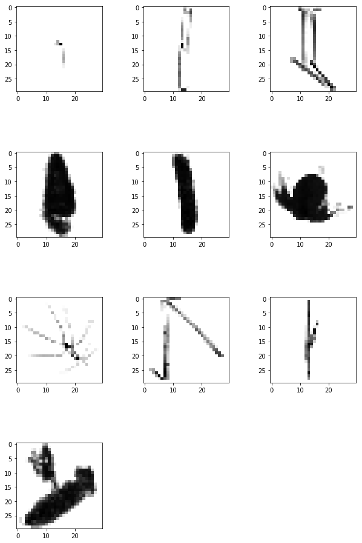

```python
for a in range(120,130):
    ax=plt.subplot(4, 3, a-119)
    plt.subplots_adjust(left  = 0.125,right =1.5, bottom = 0, top = 3, wspace = 0.2,hspace = 0.7)
    ax.imshow(X_train[a][:,:,0],cmap='gray')
plt.show()
```

**Let's see the distribution of the labels over the training data and the validation data.**

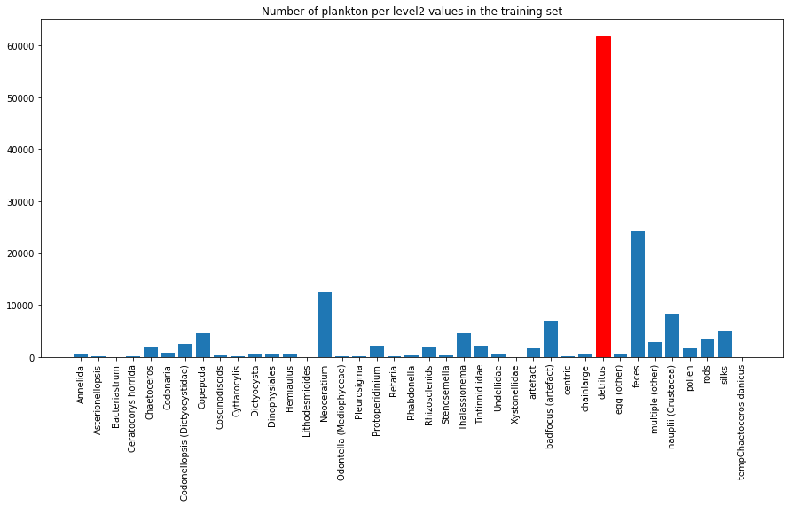

```python
warnings.filterwarnings(module='sklearn*', action='ignore', category=DeprecationWarning)


lab_int=np.argmax(Y_train,axis = 1)
# print(np.argmax(Y_train,axis = 1))

compte = {}.fromkeys(set(lab_int),0)
for valeur in lab_int:
    compte[valeur] += 1

val=[]
for i in compte.keys():
    val.append(label_encoder.inverse_transform(i))

fig = plt.figure(figsize=(15,7))
bar=plt.bar(val, compte.values())

maxis=[c for c,v in compte.items() if v==max(compte.values())]
minis=[c for c,v in compte.items() if v==min(compte.values())]

for i in maxis: #print the most represented class in red
    bar[i].set_color('r')
for i in minis: #print the less represented class in yellow
    bar[i].set_color('y')

plt.title('Number of plankton per level2 values in the training set')
plt.xticks(rotation=90)
plt.show()

del maxis
del minis
```

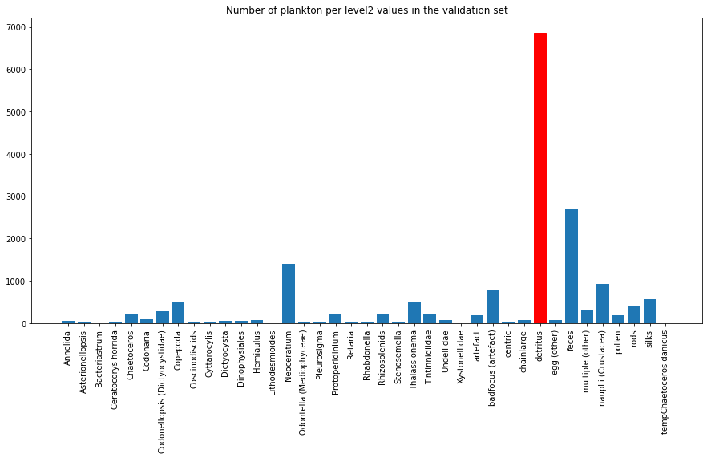

```python
lab_int=np.argmax(Y_valid,axis = 1)

compte = {}.fromkeys(set(lab_int),0)
for valeur in lab_int:
    compte[valeur] += 1

val=[]
for i in compte.keys():
    val.append(label_encoder.inverse_transform(i))

fig = plt.figure(figsize=(15,7))
bar=plt.bar(val, compte.values())

maxis=[c for c,v in compte.items() if v==max(compte.values())]
minis=[c for c,v in compte.items() if v==min(compte.values())]

for i in maxis:
    bar[i].set_color('r')
for i in minis:
    bar[i].set_color('y')

plt.title('Number of plankton per level2 values in the validation set')
plt.xticks(rotation=90)
plt.show()
```

Thanks to the stratify parameters, all classes are both in the training and the validation datasets.  
Both datasets are still skewed but it will be better with the data augmentation, done in the coming ImageDataGenerator function.

### 4. Building the model

#### Creation of the CNN

2D Maxpooling layer: we reduce by 2 the size of the output from the convolutionnal neural network. This step aims at reducing the output -feature map- size and focusing on features contained in the sub-regions. In term of performance, it reduces the computation time and it is good to reduce over-fitting by providing an abstracted form of the representation.

Then with the output from the previous layer, we feed the following convolutionnal layer and so on and so forth. We increase the number of filter at each steps to be more and more precise on the features.

Once the convolutionnal and the maxpooling steps are done, the data will be flatten before going through a dense and dropout layer.

Dense layer : This layer is a Fully Connected Neural Network. In our case, we chose 512 neurons and the activation function is relu.

Dropout : this layer consists in randomly setting to 0 some input units in order to prevent overfitting. Here, we set half of our input to 0.

After the first dropout layer, the inputs will go through another dense and dropout layer.

Finally, the data will go through the last dense layer which is the output layer. It contains 39 neurons because we have 39 different classes. The activation function is softmax to get the most probable class as an output.

```python
def create_model(optimizer):

    model = Sequential()

    model.add(Conv2D(16, kernel_size=(3, 3), padding = 'Same', activation='relu',
             input_shape=(30,30,1)))
    model.add(MaxPooling2D(pool_size=(2, 2)))

    model.add(Conv2D(64, kernel_size=(3, 3), padding = 'Same', activation='relu'))
    model.add(MaxPooling2D(pool_size=(2, 2)))

    model.add(Conv2D(128, kernel_size=(3, 3), padding = 'Same', activation='relu'))
    model.add(MaxPooling2D(pool_size=(2, 2)))

    model.add(Conv2D(256, kernel_size=(3, 3), padding = 'Same', activation='relu'))
    model.add(MaxPooling2D(pool_size=(2, 2)))

    model.add(Flatten())
    model.add(Dense(512, activation='relu'))
    model.add(Dropout(0.5))
    model.add(Dense(512, activation='relu'))
    model.add(Dropout(0.5))
    model.add(Dense(39, activation='softmax'))

    model.compile(optimizer = optimizer, loss = "categorical_crossentropy", metrics=["accuracy"])

    return model
```

#### Parameter optimisation

```python
# from keras.wrappers.scikit_learn import KerasClassifier
# from sklearn.grid_search import GridSearchCV
# from time import time
# start=time()
# model = KerasClassifier(build_fn=create_model)
# optimizers = [Adam(lr=0.1, beta_1=0.9, beta_2=0.999, epsilon=10E-8)]
# # activations = [, 'LeakyReLU']
# epochs = np.array([10,30,50])
# batches = np.array([50,80,100])
# param_grid = dict(optimizer=optimizers, nb_epoch=epochs, batch_size=batches) #nb_epoch=epochs, optimizer=optimizers, , batch_size=batches
# grid = GridSearchCV(estimator=model, param_grid=param_grid)
# grid_result = grid.fit(X_train, Y_train)
# print("Best: %f using %s" % (grid_result.best_score_, grid_result.best_params_))
# for params, mean_score, scores in grid_result.grid_scores_:
#     print("%f (%f) with: %r" % (scores.mean(), scores.std(), params))
# print("total time:",time()-start)
```

#### Data Augmentation

Rotation : We generate images rotated with a degree up to 180° degrees

Random shifts : We created shifted version of the images by applying vertical and horizontal random shifting

```python
datagen = ImageDataGenerator(
        featurewise_center=True,  # set input mean to 0 over the dataset
        samplewise_center=False,  # set each sample mean to 0
        featurewise_std_normalization=False,  # divide inputs by std of the dataset
        samplewise_std_normalization=False,  # divide each input by its std
        zca_whitening=False,  # apply ZCA whitening
        rotation_range=180,  # randomly rotate images in the range (degrees, 0 to 180)
        zoom_range = 0.1, # Randomly zoom image
        width_shift_range=0.2,  # randomly shift images horizontally (fraction of total width)
        height_shift_range=0.2,  # randomly shift images vertically (fraction of total height)
        horizontal_flip=True,  # randomly flip images
        vertical_flip=True)
```

#### Training phase

```python
epochs = 30 #number of times the network sees all the dataset
batch_size = 100 #number of images at each step of one epoch
```

```python
learning_rate_reduction = ReduceLROnPlateau(monitor='val_acc',
                                            factor=0.5,
                                            patience=3,
                                            verbose=1,
                                            min_lr=0.00001)
```

We will decrease the learning rate along the training phase to allow more fine-grained weight updates, since at the beginning weights are random and become more and more accurate along the training.  
The method here is to decrease the learning rate, dividing it by 2, when the accuracy stops improving during 3 steps in a row. verbose allows us to be aware when the learning rate decreases.

```python
model=create_model(Adam(lr=0.001, beta_1=0.9, beta_2=0.999, epsilon=10E-8))
```

**We wanted to weight our classes so that our accuracy is computed by taking in account the imbalance of our dataset. For that, we create a dictionary that contains a weight for each class accoring to it's redundancy :**

```python
from sklearn.utils.class_weight import compute_class_weight

y_integers = np.argmax(Y_train, axis=1)
class_weights = compute_class_weight('balanced', np.unique(y_integers), y_integers)
d_class_weights = dict(enumerate(class_weights))
```

```python
history = model.fit_generator(datagen.flow(X_train,Y_train, batch_size=batch_size,shuffle=True),
                              epochs = epochs, validation_data = (X_valid,Y_valid),
                              verbose = 2, steps_per_epoch=X_train.shape[0] // batch_size, class_weight=d_class_weights, callbacks=[learning_rate_reduction])
```

```
 - 153s - loss: 3.4128 - acc: 0.0293 - val_loss: 3.2545 - val_acc: 0.0739
 - 153s - loss: 3.0887 - acc: 0.0375 - val_loss: 3.2755 - val_acc: 0.1012
 - 157s - loss: 2.8989 - acc: 0.0583 - val_loss: 3.2891 - val_acc: 0.0856
 - 154s - loss: 2.8762 - acc: 0.0593 - val_loss: 3.4868 - val_acc: 0.0970
 - 153s - loss: 2.8039 - acc: 0.0766 - val_loss: 3.4208 - val_acc: 0.0963

Epoch 00005: ReduceLROnPlateau reducing learning rate to 0.0005000000237487257.
 - 156s - loss: 2.6969 - acc: 0.1035 - val_loss: 3.1231 - val_acc: 0.1271
 - 156s - loss: 2.6586 - acc: 0.1155 - val_loss: 3.0392 - val_acc: 0.1251
 - 158s - loss: 2.6373 - acc: 0.1155 - val_loss: 3.1017 - val_acc: 0.1361
 - 156s - loss: 2.6292 - acc: 0.1281 - val_loss: 3.0906 - val_acc: 0.1492
 - 159s - loss: 2.5831 - acc: 0.1329 - val_loss: 2.9742 - val_acc: 0.1606
 - 156s - loss: 2.5649 - acc: 0.1408 - val_loss: 3.0645 - val_acc: 0.1449
 - 155s - loss: 2.5958 - acc: 0.1335 - val_loss: 3.3036 - val_acc: 0.0705
 - 157s - loss: 2.5683 - acc: 0.1297 - val_loss: 2.9934 - val_acc: 0.1626
 - 155s - loss: 2.5436 - acc: 0.1483 - val_loss: 3.0427 - val_acc: 0.1568
 - 159s - loss: 2.6267 - acc: 0.1233 - val_loss: 3.1733 - val_acc: 0.1516
 - 154s - loss: 2.5598 - acc: 0.1436 - val_loss: 3.1049 - val_acc: 0.1597

Epoch 00016: ReduceLROnPlateau reducing learning rate to 0.0002500000118743628.
 - 149s - loss: 2.4793 - acc: 0.1632 - val_loss: 2.9050 - val_acc: 0.1777
 - 150s - loss: 2.4481 - acc: 0.1793 - val_loss: 3.0090 - val_acc: 0.1569
 - 153s - loss: 2.4411 - acc: 0.1679 - val_loss: 3.0110 - val_acc: 0.1707
 - 152s - loss: 2.4062 - acc: 0.1827 - val_loss: 2.8868 - val_acc: 0.1815
 - 157s - loss: 2.4215 - acc: 0.1710 - val_loss: 3.2235 - val_acc: 0.0822
 - 156s - loss: 2.4240 - acc: 0.1704 - val_loss: 2.9142 - val_acc: 0.1772
 - 155s - loss: 2.3662 - acc: 0.1872 - val_loss: 3.0379 - val_acc: 0.1762

Epoch 00023: ReduceLROnPlateau reducing learning rate to 0.0001250000059371814.
 - 151s - loss: 2.3428 - acc: 0.1864 - val_loss: 3.0382 - val_acc: 0.1721
 - 157s - loss: 2.3565 - acc: 0.1926 - val_loss: 3.0049 - val_acc: 0.1742
 - 160s - loss: 2.3160 - acc: 0.1974 - val_loss: 2.7623 - val_acc: 0.2000
 - 158s - loss: 2.3476 - acc: 0.1982 - val_loss: 3.0515 - val_acc: 0.1678
 - 154s - loss: 2.3172 - acc: 0.1999 - val_loss: 2.9603 - val_acc: 0.1880
 - 155s - loss: 2.2868 - acc: 0.2071 - val_loss: 3.0477 - val_acc: 0.1836

Epoch 00029: ReduceLROnPlateau reducing learning rate to 6.25000029685907e-05.
 - 156s - loss: 2.2791 - acc: 0.2066 - val_loss: 3.0908 - val_acc: 0.1851
```

**The validation accuracy is better than the training accuracy at the beginning. This can be explained by the fact that we use dropout layers so the model will have a different behavior with training and validation data.**

### 5. Model evaluation

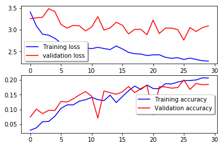

```python
fig, ax = plt.subplots(2,1)
ax[0].plot(history.history['loss'], color='b', label="Training loss")
ax[0].plot(history.history['val_loss'], color='r', label="validation loss",axes =ax[0])
legend = ax[0].legend(loc='best', shadow=True)

ax[1].plot(history.history['acc'], color='b', label="Training accuracy")
ax[1].plot(history.history['val_acc'], color='r',label="Validation accuracy")
legend = ax[1].legend(loc='best', shadow=True)
```

#### F1 score

```python
Y_predicted = model.predict(X_valid)
y_pred = np.argmax(Y_predicted,axis = 1) #labels predicted by the model

y_true = np.argmax(Y_valid,axis = 1) #true  labels
```

```python
from sklearn.metrics import f1_score
f1_score(y_true, y_pred, average='macro')
```

```
0.1330221676200917
```

We can see that we have 13% on the F1 score, which is not a very good score.  
We can explain this by the fact that the quality of the image if very bad because of its small size (30,30), and therefore we don't have enough pixels to help the neural network distinguish between all the different classes.

#### Confusion matrix

```
Confusion matrix, without normalization
```

[figure not shown]

```python
from sklearn import svm, datasets
from sklearn.model_selection import train_test_split
from sklearn.metrics import confusion_matrix
from sklearn.utils.multiclass import unique_labels

class_names=values

def plot_confusion_matrix(y_true, y_pred, classes,
                          normalize=False,
                          title=None,
                          cmap=plt.cm.Blues):
    if not title:
        if normalize:
            title = 'Normalized confusion matrix'
        else:
            title = 'Confusion matrix, without normalization'

    # Compute confusion matrix
    cm = confusion_matrix(y_true, y_pred)
    # Only use the labels that appear in the data
    classes = classes[unique_labels(y_true, y_pred)]
    if normalize:
        cm = cm.astype('float') / cm.sum(axis=1)[:, np.newaxis]
        print("Normalized confusion matrix")
    else:
        print('Confusion matrix, without normalization')

    fig, ax = plt.subplots(figsize=(25, 15))
    im = ax.imshow(cm, interpolation='nearest', cmap=cmap)
    ax.figure.colorbar(im, ax=ax)
    ax.set(xticks=np.arange(cm.shape[1]),
           yticks=np.arange(cm.shape[0]),
           xticklabels=classes, yticklabels=classes,
           title=title,
           ylabel='True label',
           xlabel='Predicted label')

    # Rotate the tick labels and set their alignment.
    plt.setp(ax.get_xticklabels(), rotation=45, ha="right",
             rotation_mode="anchor")

    # Loop over data dimensions and create text annotations.
    fmt = '.2f' if normalize else 'd'
    thresh = cm.max() / 2.
    for i in range(cm.shape[0]):
        for j in range(cm.shape[1]):
            ax.text(j, i, format(cm[i, j], fmt),
                    ha="center", va="center",
                    color="white" if cm[i, j] > thresh else "black")
    fig.tight_layout()
    return ax

np.set_printoptions(precision=2)

# Plot non-normalized confusion matrix
plot_confusion_matrix(y_pred, y_true,classes=class_names,
                      title='Confusion matrix, without normalization')

# # Plot normalized confusion matrix
# plot_confusion_matrix(y_pred, y_true, classes=class_names, normalize=True,
#                       title='Normalized confusion matrix')

plt.show()
```

#### Exemple of errors made by the network

**We show 6 images with their predicted and real labels.**

[figure not shown]

```python
# Display some error results

# Errors are difference between predicted labels and true labels
errors = (y_pred - y_true != 0)

Y_pred_classes_errors = y_pred[errors]
Y_pred_errors = Y_predicted[errors]
Y_true_errors = y_true[errors]
X_val_errors = X_valid[errors]

def display_errors(errors_index,img_errors,pred_errors, obs_errors):
    n = 0
    nrows = 2
    ncols = 3
    fig, ax = plt.subplots(nrows,ncols,sharex=True,sharey=True)
    plt.subplots_adjust(left  = 0.125,right =1.5, bottom = 0, top = 1, wspace = 0.2,hspace = 0.7)
    for row in range(nrows):
        for col in range(ncols):
            error = errors_index[n]
            ax[row,col].imshow((img_errors[error]).reshape((30,30)),cmap='gray')
            ax[row,col].set_title("True label :{}\nPredicted label :{}".format(label_encoder.inverse_transform(pred_errors[error]),
                                                                               label_encoder.inverse_transform(obs_errors[error])))
            n += 1

# Probabilities of the wrong predicted numbers
Y_pred_errors_prob = np.max(Y_pred_errors,axis = 1)

# Predicted probabilities of the true values in the error set
true_prob_errors = np.diagonal(np.take(Y_pred_errors, Y_true_errors, axis=1))

# Difference between the probability of the predicted label and the true label
delta_pred_true_errors = Y_pred_errors_prob - true_prob_errors

# Sorted list of the delta prob errors
sorted_dela_errors = np.argsort(delta_pred_true_errors)

# Top 6 errors
most_important_errors = sorted_dela_errors[-6:]

# Show the top 6 errors
display_errors(most_important_errors, X_val_errors, Y_pred_classes_errors, Y_true_errors)
```

#### Transfer Learning

One of the most popular techniques in Deep Learning, and especially in computer vision and object recognition is transfer learning.  
The basic idea is to load a pre-trained model, in our case we took ResNet50 which is a 50 layer Residual network, and use it as the strating point, to take advantage of the full knowledge of it.  
This approach has two main advantages:  
1- Performance: We know that our model has already been trained on a huge dataset called ImageNet (14 million images), so this will help us to avoid having an extremely large dataset.  
This photo shows the impact of transfer learning on performance :  
2- Computational power : As we are using pre-trained weights of the ResNet, we only have to learn the weights of the last few layers, so we are going to freeze the layers of ResNet, and this will save us lot of computational time.  
The Last Fully connected layer of ResNet50 will be deleted and replaced by a new one with only 39 neurons to make the multi labels classification on planktons.  
However, we may say that ResNet50 have been trained on a very different dataset which is ImageNet and may not behave well on a plankton dataset, but the thing is that these two datasets share in the beginning the same useful visual features: edges,shapes and different intensities of light and dark pixels, etc...  
The filters of the first layers of our model already know how to recognize horizontal and vertical lines, the next few ones to recognize trivial shapes using the lines learned in the previous layer, this goes further until we reach the last layers which will able to detect which kind of plankton it is.  
the ResNet50 accepts only RGB images, and since our images are grayscale images, we took the first layer of the RGB that accepts RGB images and computed the mean of each filter by adding up the three filters one for each dimension, so that in the end we can have one filter that accept images with one channel. These two photos illustrate the idea of transfer learning and also the impact they can have on performance :

[figure not shown]

However, we tried to use transfer learning but we actually had a problem with validation data, which was not increasing at all from the beginning, even if the accuracy on the training was increasing(if the picture we don't see it a lot but it was the case before), and we didn't know how to solve it so that's why we implemented our own architecture of the neural network.

[figure not shown]

#### * Attributes in features_native.csv.gz

A brief outline of the availabel attributes in `features_native.csv.gz` which you can use is given below:

- *objid*: same as in `meta.csv`
- *area*: area of ROI
- *meanimagegrey*:
- *mean*: mean grey
- *stddev*: standard deviation of greys
- *min*: minimum grey
- *perim.*: perimeter of ROI
- *width, height*: dimensions of ROI
- *major, minor*: length of major,minor axis of the best fitting ellipse
- *angle*:
- *circ.*: circularity or shape factor which can be computed by 4pi(area/perim.^2)
- *feret*: maximal feret diameter
- *intden*: integrated density: mean*area
- *median*: median grey
- *skew, kurt*: skewness,kurtosis of the histogram of greys
- *%area*: proportion of the image corresponding to the object
- *area_exc*: area excluding holes
- *fractal*: fractal dimension of the perimeter
- *skelarea*: area of the one-pixel wide skeleton of the image ???
- *slope*: slope of the cumulated histogram of greys
- *histcum1, 2, 3*: grey level at quantiles 0.25, 0.5, 0.75 of the histogram of greys
- *nb1, 2, 3*: number of objects after thresholding at the grey levels above
- *symetrieh, symetriev*: index of horizontal,vertical symmetry
- *symetriehc, symetrievc*: same but after thresholding at level histcum1
- *convperim, convarea*: perimeter,area of the convex hull of the object
- *fcons*: contrast
- *thickr*: thickness ratio: maximum thickness/mean thickness
- *esd*:
- *elongation*: elongation index: major/minor
- *range*: range of greys: max-min
- *meanpos*: relative position of the mean grey: (max-mean)/range
- *centroids*:
- *cv*: coefficient of variation of greys: 100*(stddev/mean)
- *sr*: index of variation of greys: 100*(stddev/range)
- *perimareaexc*:
- *feretareaexc*:
- *perimferet*: index of the relative complexity of the perimeter: perim/feret
- *perimmajor*: index of the relative complexity of the perimeter: perim/major
- *circex*:
- *cdexc*:
- *kurt_mean*:
- *skew_mean*:
- *convperim_perim*:
- *convarea_area*:
- *symetrieh_area*:
- *symetriev_area*:
- *nb1_area*:
- *nb2_area*:
- *nb3_area*:
- *nb1_range*:
- *nb2_range*:
- *nb3_range*:
- *median_mean*:
- *median_mean_range*:
- *skeleton_area*:

#### * Attributes in features_skimage.csv.gz

Table of morphological features recomputed with skimage.measure.regionprops on the ROIs produced by ZooProcess. See http://scikit-image.org/docs/dev/api/skimage.measure.html#skimage.measure.regionprops for documentation.